# Prediction of Hospital capacity needs

Group work Busschers, Dherbomez, Mather, Van der Meer

1 Feb 2017

# **Part 1.** Introduction to the business project

## Objective

The objective is to predict hospital capacity need and composition for (area’s in) the Netherlands for the next 25 years. Broadly, a hospital consists of 6 different parts, which have very different usage, building requirements and costs:

1. Outpatient beds
2. Inpatient beds
3. Outpatient operating rooms
4. Inpatient operating rooms
5. Consultation rooms
6. Imaging diagnostics rooms

## Business use

A number of stakeholders would use these predictions for their decision-making process. Building a new hospital or rebuilding an outmoded hospital is a very expensive process (~200-500M EUR) with a long lead time (from design to finish ~5 years). This brings along significant uncertainty of the future demand. Hospitals are developed for a usage period of about 20-30 years. Therefore, different parties, directly and indirectly, involved in the building and financing of a hospital benefit from better estimations of the future demand for the hospital:

1. Hospitals: deciding on (re)building a hospital and the size and composition
2. Banks: assessing investment proposals
3. Insurers: assessing financing decision for (part of) the build, pricing of provided care, contract negotiations with hospitals
4. (Local) governments: assessing financing decision for (part of) the build, assessing whether care is sufficiently ensured for the inhabitants

# **Part 2.** Process

We follow a number of predefined steps in this project, which can be grouped in thre three categories: getting the data ready, doing the calculations, and showing the results. The process is:

1. Getting the data ready
   1. Collect data from the different sources
   2. Clean the data (for example remove double headers)
   3. Do sanity checks and cross check the data against each other (for example, there should be ~17M people in 2017 in the country)
   4. Visualize and summarize the data
   5. Check how data can be matched and which assumptions are needed (for example for outpatient visits, we don’t have information on age and gender, so we will assume that distribution is equal to that of outpatient admissions)
2. Perform calculations
   1. Count number of activities in 6 categories (outpatient admissions, inpatient nursing days, outpatient surgeries, inpatient surgeries, outpatient visits, imaging diagnostics) per region, age and gender
   2. Multiply number of activities with the corresponding space requirement in m2 to get required m2 per type of space, region in Netherlands, gender and age
   3. Multiply with demography developments to get required m2 per type of space, region in Netherlands, gender and age for the years 2018-2040.
3. Visualize results per year and type of space

# **Part 3.** Data

## Description

All data is publicly available through www.cbs.nl and www.opendis.nl. We will use three different types of data:

## Gathering and cleaning

We read our data files. The relevant information has to be extracted and put in a common format

The first dataset is the population forecast per year from 2014 to 2040, per region, type of region(city or land) and gender. This is how the first lines of the data looks:

|  | Year | Region | Type.of.region | Gender | Age | Population_x1000 |
| --- | --- | --- | --- | --- | --- | --- |
| 01 | 2014 | Alkmaar | City | Mannen | Totaal leeftijd | 46.6 |
| 02 | 2014 | Alkmaar | City | Mannen | 0 tot 5 jaar | 2.8 |
| 03 | 2014 | Alkmaar | City | Mannen | 5 tot 10 jaar | 2.6 |
| 04 | 2014 | Alkmaar | City | Mannen | 10 tot 15 jaar | 2.7 |
| 05 | 2014 | Alkmaar | City | Mannen | 15 tot 20 jaar | 2.5 |

The second dataset provides the surface requirement in m² for the various activities that need to be performed

|  | Dutch.name.activity.cluster | Englisch.name.activity.cluster | Bruto.space.per.activity | Activity.related.space | Surcharge | Total.normative.space |
| --- | --- | --- | --- | --- | --- | --- |
| 01 | Dagverpleging | Day admissions | 0.076 | 0.000 | 0.012 | 0.088 |
| 02 | Verpleegdagen | Nursing days | 0.120 | 0.054 | 0.032 | 0.206 |
| 03 | Polikliniek | Outpatient visits | 0.027 | 0.024 | 0.009 | 0.060 |
| 04 | Operaties | Surgeries | 0.154 | 0.112 | 0.042 | 0.308 |
| 05 | Beeldvormende diagnostiek | Imaging diagnostics | 0.019 | 0.000 | 0.004 | 0.023 |

the next dataset provides the number of surgeries performed per gender and age between 1995 and 2010. These data required a first cleaning, as it was incomplete. the missing information is replaced by 0 to obtain a clean table that we can work with

|  | Surgery | Year | Gender | Age | Total_surgeries | Total_surgeries_per_10000_inhabitants | Inpatient_surgeries | Inpatient_surgeries_per_10000_inhabitants | Outpatient_surgeries | Outpatient_surgeries_per_10000_inhabitants |
| --- | --- | --- | --- | --- | --- | --- | --- | --- | --- | --- |
| 01 | All | 1995 | Mannen | 0 tot 20 jaar | 127928 | 664.9 | 33696 | 175.1 | 94232 | 489.7 |
| 02 | All | 1995 | Mannen | 20 tot 45 jaar | 120332 | 386.5 | 76578 | 246 | 43754 | 140.5 |
| 03 | All | 1995 | Mannen | 45 tot 65 jaar | 108633 | 608.9 | 81900 | 459.1 | 26733 | 149.8 |
| 04 | All | 1995 | Mannen | 65 tot 80 jaar | 87010 | 1284.4 | 75760 | 1118.3 | 11250 | 166.1 |
| 05 | All | 1995 | Mannen | 80 jaar of ouder | 21813 | 1511 | 19055 | 1319.9 | 2758 | 191 |

The next dataset indexes some information on hospital admissions per gender and age from 1981 and 2012

|  | Year | Gender | Age | Total_admissions_per_10000_inhabitants | Outpatient_admissions_per_10000_inhabitants | Inpatient_admissions_per_10000_inhabitants | Nursingdays_per_10000_inhabitants | Average_nursing_days_per_inpatient_admission | Average_poulation |
| --- | --- | --- | --- | --- | --- | --- | --- | --- | --- |
| 01 | 1981 | Mannen | 0 jaar | 0 | 0 | 7419.4 | 73696.9 | 9.9 | 90907 |
| 02 | 1981 | Mannen | 1 tot 20 jaar | 0 | 0 | 657.4 | 5563.1 | 8.5 | 2140447 |
| 03 | 1981 | Mannen | 20 tot 45 jaar | 0 | 0 | 616.2 | 6703.7 | 10.9 | 2771806 |
| 04 | 1981 | Mannen | 45 tot 65 jaar | 0 | 0 | 1238.6 | 17623.5 | 14.2 | 1383986 |
| 05 | 1981 | Mannen | 65 tot 80 jaar | 0 | 0 | 2263.6 | 42526.7 | 18.8 | 560848 |

The next dataset gives the number of details activities per specialisation. Several reference tables are also read to interpret the activities, DOT’s and specialisations

|  | VERSIE | DATUM_BESTAND | PEILDATUM | JAAR | BEHANDELEND_SPECIALISME_CD | TYPERENDE_DIAGNOSE_CD | ZORGPRODUCT_CD | ZORGACTIVITEIT_CD | ZORGPROFIELKLASSE_CD | AANTAL_PAT | AANTAL_SUBTRAJECT | AANTAL_ZAT |
| --- | --- | --- | --- | --- | --- | --- | --- | --- | --- | --- | --- | --- |
| 01 | 1 | 2017-01-16 | 2017-01-01 | 2014 | 301 | 101 | 79699007 | 39813 | 4 | 115 | 116 | 123 |
| 02 | 1 | 2017-01-16 | 2017-01-01 | 2014 | 301 | 101 | 79699007 | 39823 | 4 | 62 | 62 | 85 |
| 03 | 1 | 2017-01-16 | 2017-01-01 | 2014 | 301 | 101 | 79699013 | 82042 | 7 | 4 | 4 | 4 |
| 04 | 1 | 2017-01-16 | 2017-01-01 | 2014 | 301 | 102 | 79699007 | 39824 | 4 | 9 | 9 | 12 |
| 05 | 1 | 2017-01-16 | 2017-01-01 | 2014 | 301 | 102 | 79699008 | 190060 | 1 | 13 | 13 | 18 |

|  | VERSIE | DATUM_BESTAND | PEILDATUM | ZORGACTIVITEIT_CD | OMSCHRIJVING | ZORGPROFIELKLASSE_CD | ZORGPROFIELKLASSE_OMS |
| --- | --- | --- | --- | --- | --- | --- | --- |
| 01 | 1 | 2017-01-16 | 2017-01-01 | 35135 | Niet operatieve ambulante behandeling van haemorrhoÃ¯den door middel van scleroseren, bandligatie, infraroodcoagulatie of cryochirurgie. De eerste behandeling. | 5 | OPERATIEVE VERRICHTINGEN |
| 02 | 1 | 2017-01-16 | 2017-01-01 | 39239 | Selectie allogeen navelstrengbloed bij stamceltransplantatie. | 6 | OVERIGE THERAPEUTISCHE ACTIVITEITEN |
| 03 | 1 | 2017-01-16 | 2017-01-01 | 90707 | Fusie van image-datasets tbv treatment planning. | 6 | OVERIGE THERAPEUTISCHE ACTIVITEITEN |
| 04 | 1 | 2017-01-16 | 2017-01-01 | 39760 | Brainstem auditory evoked potentials (BAEP/BER) met auto-akoestische emissie. | 4 | DIAGNOSTISCHE ACTIVITEITEN |
| 05 | 1 | 2017-01-16 | 2017-01-01 | 38440 | Cervicale discectomie. | 5 | OPERATIEVE VERRICHTINGEN |

|  | VERSIE | DATUM_BESTAND | PEILDATUM | DIAGNOSE_CD | SPECIALISME_CD | DIAGNOSE_OMSCHRIJVING |
| --- | --- | --- | --- | --- | --- | --- |
| 01 | 1 | 2017-01-16 | 2017-01-01 | 51 | 302 | Afwijkingen mondholte |
| 02 | 1 | 2017-01-16 | 2017-01-01 | 1567 | 305 | Overige enthesopathie elleboog/onderarm |
| 03 | 1 | 2017-01-16 | 2017-01-01 | 999 | 362 | ICC |
| 04 | 1 | 2017-01-16 | 2017-01-01 | 109 | 318 | leverbiopt |
| 05 | 1 | 2017-01-16 | 2017-01-01 | 121 | 318 | videocapsule endoscopie |

|  | VERSIE | DATUM_BESTAND | PEILDATUM | ZORGPRODUCT_CD | LATIJN_OMS | CONSUMENT_OMS | DECLARATIE_VERZEKERD_CD | DECLARATIE_ONVERZEKERD_CD |
| --- | --- | --- | --- | --- | --- | --- | --- | --- |
| 01 | 1 | 2017-01-16 | 2017-01-01 | 149599001 | Uitval standaard \| Urogenitaal glomeruli/nier/ureter |  |  |  |
| 02 | 1 | 2017-01-16 | 2017-01-01 | 69499005 | Uitval intensieve/ invasieve therapie \| Snijdende specialismen \| Carpaaltunnelsyndroom \| Zenuwstelsel zenuw/-wortel/-plexus |  |  |  |
| 03 | 1 | 2017-01-16 | 2017-01-01 | 109599015 | Uitval intensieve/ invasieve therapie \| Ademh pleura |  |  |  |
| 04 | 1 | 2017-01-16 | 2017-01-01 | 29999015 | Uitval niet operatief \| Wervelkolom \| Nieuwv benigne/onbek ov/nno |  |  |  |
| 05 | 1 | 2017-01-16 | 2017-01-01 | 990016351 | Diagnosen gastroenterologie overig \| Klin kort \| Met GE activiteiten specifiek \| Kindergeneeskunde | Maximaal 5 verpleegligdagen (met behandeling of onderzoek door de maag-darm-leverarts) bij Een aandoening van maag / darm / lever | 14B801 |  |

|  | VERSIE | DATUM_BESTAND | PEILDATUM | SPECIALISME_CD | OMSCHRIJVING |
| --- | --- | --- | --- | --- | --- |
| 01 | 1 | 2017-01-16 | 2017-01-01 | 303 | Medisch specialisten, chirurgie |
| 02 | 1 | 2017-01-16 | 2017-01-01 | 458 | Fysiotherapeuten, manuele therapie, kinderfysiotherapie, oedeemtherapie en geriatrie |
| 03 | 1 | 2017-01-16 | 2017-01-01 | 9457 | Psychologische zorgverleners, kinder- en jeugdpsycholoog NIP, GZ-psychologie, 1e lijn |
| 04 | 1 | 2017-01-16 | 2017-01-01 | 7695 | Leveranciers hulpmiddelen, hulpmiddelen voor communicatie, informatie en signalering |
| 05 | 1 | 2017-01-16 | 2017-01-01 | 8404 | Overige artsen, irisscopie |

To ease the data cleaning, we are also loading a technical table which identifies the various age groups and gender, as these are not homogeneous across the raw data

|  | Gender | Forecast_age | Adm_age | Surg_Age | Age_gender_ID |
| --- | --- | --- | --- | --- | --- |
| 01 | Mannen | Totaal leeftijd |  |  | 0 |
| 02 | Mannen | 0 tot 5 jaar | 0 jaar | 0 tot 20 jaar | 1 |
| 03 | Mannen | 5 tot 10 jaar | 1 tot 20 jaar | 0 tot 20 jaar | 1 |
| 04 | Mannen | 10 tot 15 jaar | 1 tot 20 jaar | 0 tot 20 jaar | 1 |
| 05 | Mannen | 15 tot 20 jaar | 1 tot 20 jaar | 0 tot 20 jaar | 1 |

## Sanity checks

In the graphs below we show how much the total number of activities from the two sources that we use, deviates from the values that we expected. The expected values are based on open sources that state how many surgeries, nursing days, outpatient admisssions, consultations and imaging diagnostics have taken place in 2014. Due tot he quality of these height level estimates and our data, a deviation up till 20% can be accepted. We see some difference that are bigger, but we can explain these. In OpenDis we see less imaging diagnostics than we would expect. It could be that the reported number contains also imaging diagnostics done by private clinics, which we didn’t include in our analysis. The inpatient surgeries number is too high, which is due to some activities that are classified as surgical, but are no stand-alone surgeries. This may cause the double counting by ~ 35%.

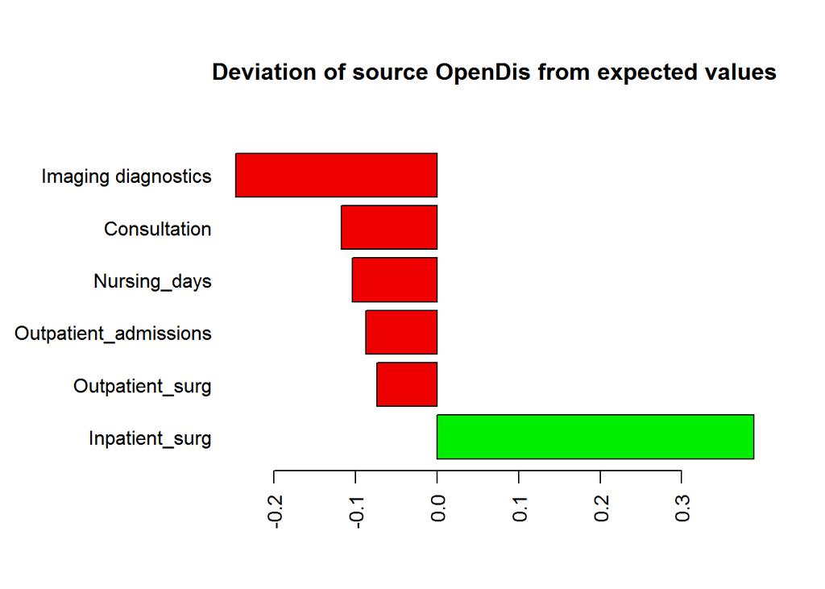

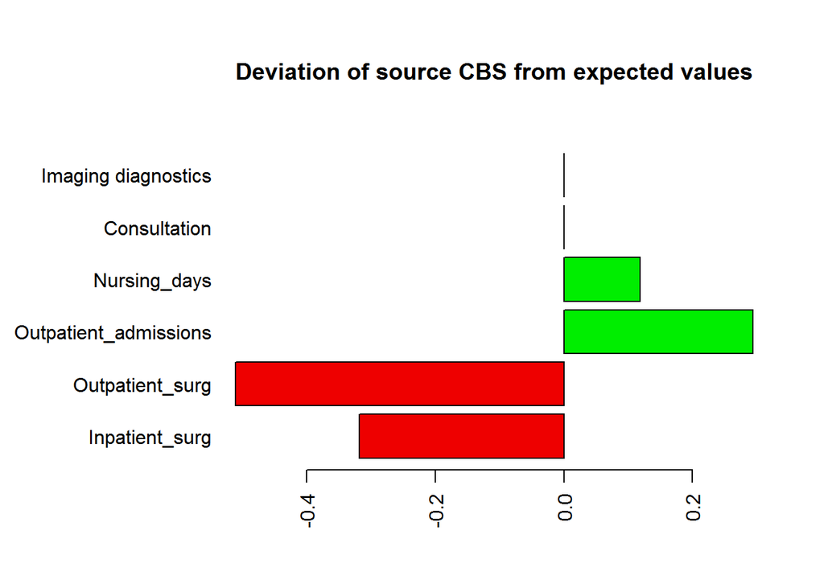

## Summary and visualisation

To show how the demography of the population changes, we visualize the composition of the population in 2014 and 2040.

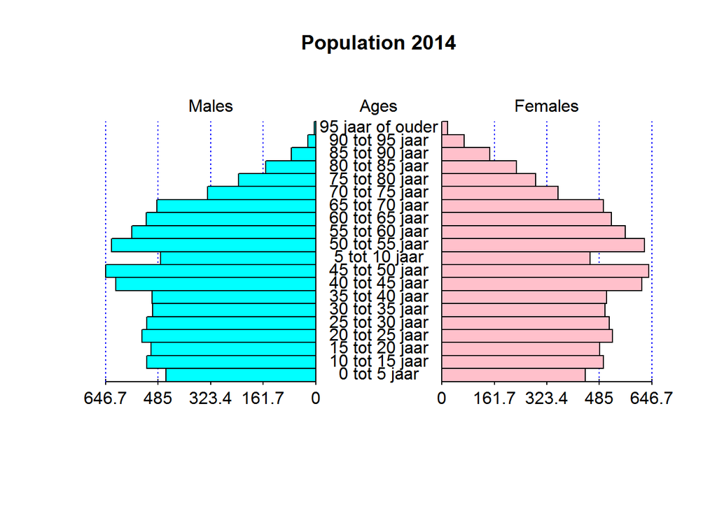

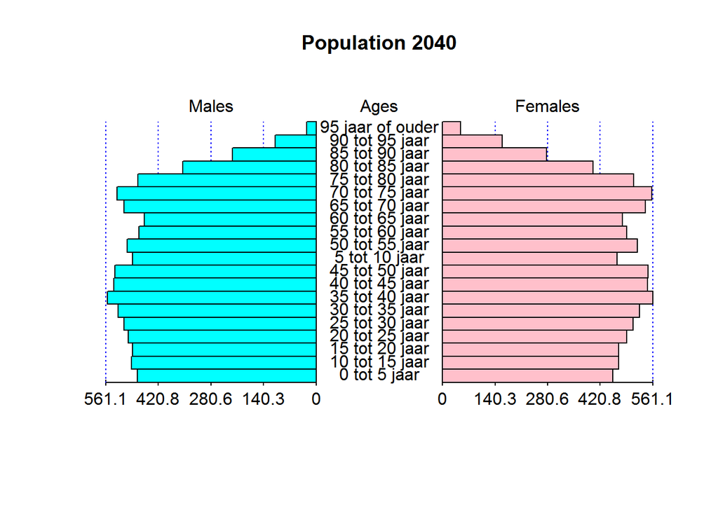

# **Part 4.** Calculations

## Preparation of data

As visualized above, the raw data that we are getting from the various sources are not homogeneous. we need to organize and combine them in order to be able to use them together and draw the projections up to 2040.

we start by adding the Age/gender ID to the population forecast table to be able to perform projections later on

|  | Age_gender_ID | Age | Gender | Number_of_act | Type_act | Population_x1000 | Act_per_1000inhab | Space_per_act |
| --- | --- | --- | --- | --- | --- | --- | --- | --- |
| 01 | 1 | 0 tot 20 jaar | Mannen | 25159 | Inpatient_surg | 1966.4 | 12.79445 | 0.308 |
| 02 | 2 | 20 tot 45 jaar | Mannen | 53447 | Inpatient_surg | 2676.3 | 19.97048 | 0.308 |
| 03 | 3 | 45 tot 65 jaar | Mannen | 91737 | Inpatient_surg | 2363.3 | 38.81733 | 0.308 |
| 04 | 4 | 65 tot 80 jaar | Mannen | 80815 | Inpatient_surg | 1059.1 | 76.30535 | 0.308 |
| 05 | 5 | 80 jaar of ouder | Mannen | 23903 | Inpatient_surg | 258.2 | 92.57552 | 0.308 |

|  | Age_gender_ID | Age | Gender | Number_of_act | Type_act | Population_x1000 | Act_per_1000inhab | Space_per_act |
| --- | --- | --- | --- | --- | --- | --- | --- | --- |
| 01 | 1 | 0 tot 20 jaar | Mannen | 83434 | Outpatient_surg | 1966.4 | 42.42982 | 0.308 |
| 02 | 2 | 20 tot 45 jaar | Mannen | 61101 | Outpatient_surg | 2676.3 | 22.83040 | 0.308 |
| 03 | 3 | 45 tot 65 jaar | Mannen | 98012 | Outpatient_surg | 2363.3 | 41.47252 | 0.308 |
| 04 | 4 | 65 tot 80 jaar | Mannen | 72064 | Outpatient_surg | 1059.1 | 68.04268 | 0.308 |
| 05 | 5 | 80 jaar of ouder | Mannen | 22793 | Outpatient_surg | 258.2 | 88.27653 | 0.308 |

The raw data with the admissions give information on the needed inpatient beds (the nursing days) and outpatient beds (beds used for day admissions) per 10,000 inhabitant. We work the data in order to obtain a table with one column indexing all the different types of activities and their occurence, per age and gender type. The data is extrated for the year 2012 only, because we want to forecast based on the most recent available data.

|  | Age_gender_ID | Age | Gender | Number_of_act | Type_act | Population_x1000 | Act_per_1000inhab | Space_per_act |
| --- | --- | --- | --- | --- | --- | --- | --- | --- |
| 01 | 1 | 0 tot 20 jaar | Mannen | 634152.9 | Nursing_days | 1966.4 | 322.4944 | 0.206 |
| 02 | 2 | 20 tot 45 jaar | Mannen | 490935.4 | Nursing_days | 2676.3 | 183.4381 | 0.206 |
| 03 | 3 | 45 tot 65 jaar | Mannen | 1327179.1 | Nursing_days | 2363.3 | 561.5788 | 0.206 |
| 04 | 4 | 65 tot 80 jaar | Mannen | 1666094.0 | Nursing_days | 1059.1 | 1573.1225 | 0.206 |
| 05 | 5 | 80 jaar of ouder | Mannen | 741831.2 | Nursing_days | 258.2 | 2873.0876 | 0.206 |

|  | Age_gender_ID | Age | Gender | Number_of_act | Type_act | Population_x1000 | Act_per_1000inhab | Space_per_act |
| --- | --- | --- | --- | --- | --- | --- | --- | --- |
| 01 | 1 | 0 tot 20 jaar | Mannen | 127986.30 | Outpatient_admissions | 1966.4 | 65.08661 | 0.088 |
| 02 | 2 | 20 tot 45 jaar | Mannen | 154079.70 | Outpatient_admissions | 2676.3 | 57.57191 | 0.088 |
| 03 | 3 | 45 tot 65 jaar | Mannen | 341456.42 | Outpatient_admissions | 2363.3 | 144.48289 | 0.088 |
| 04 | 4 | 65 tot 80 jaar | Mannen | 304688.03 | Outpatient_admissions | 1059.1 | 287.68580 | 0.088 |
| 05 | 5 | 80 jaar of ouder | Mannen | 85805.62 | Outpatient_admissions | 258.2 | 332.32230 | 0.088 |

The last two activities we want insights on are the consultation and imaging diagnostics. The information is included in the raw data with all healthcare activities that are claimed at the Dutch insurance companies. We will use the most recent year that has been (almost) fully claimed, which is the year 2014.

|  | Age_gender_ID | Age | Gender | Number_of_act | Type_act | Population_x1000 | Act_per_1000inhab | Space_per_act |
| --- | --- | --- | --- | --- | --- | --- | --- | --- |
| 01 | 1 | 0 tot 20 jaar | Mannen | 2954245 | Consultation | 1966.4 | 1502.3622 | 0.06 |
| 02 | 2 | 20 tot 45 jaar | Mannen | 2163475 | Consultation | 2676.3 | 808.3828 | 0.06 |
| 03 | 3 | 45 tot 65 jaar | Mannen | 3470426 | Consultation | 2363.3 | 1468.4661 | 0.06 |
| 04 | 4 | 65 tot 80 jaar | Mannen | 2551655 | Consultation | 1059.1 | 2409.2673 | 0.06 |
| 05 | 5 | 80 jaar of ouder | Mannen | 807058 | Consultation | 258.2 | 3125.7088 | 0.06 |

[output not shown]

[output not shown]

## Assumptions

We had to make a number of assumptions, because the data is not as complete as hoped for:

1. Since the surgery data is only available up till 2010, we needed to assume that this is still representative for 2014. The same holds for admissions till 2012.
2. We assume that the current state of care does not change, only the population size and distribution of age-gender changes. However, in reality we would expect innovation to change the form of care and days we spend in a hospital to change as well.
3. We made a shortcut by using different years for different types of activities (ranging from 2010 to 2014), but applying the same number of inhabitants (namely of the year 2014) to it. This made calculations much easier and was the available data. The impact of this is probably very small, due to the fact that population does not change to much in 4 years.
4. For the consultations and imaging diagnostics we had to make an assumption on how the total number of activities is currently distributed over age-gender, because we don’t have this level of detail in the data. We assumed that these activities are the same distributed as outpatient admissions.

## Implementation

To build our projection, we are combining the data from the population forecast and the activities table for 2014. We basically perform the following steps: a. Count number of activities in 6 categories (outpatient admissions, inpatient nursing days, outpatient surgeries, inpatient surgeries, outpatient visits, imaging diagnostics) per region, age and gender

2. Multiply number of activities with the corresponding space requirement in m2 to get required m2 per type of space, region in Netherlands, gender and age
3. Multiply with demography developments to get required m2 per type of space, region in Netherlands, gender and age for the years 2018-2040.

Now that we have the detailed projections, we want sum the required surfaces on the Age and Gender to obtain statistics per Region and Activity.

|  | Year | Region | Activity | Space_x1000m2 |
| --- | --- | --- | --- | --- |
| 01 | 2014 | ’s-Gravenhage (gemeente) | Consultation | 45 |
| 02 | 2015 | ’s-Gravenhage (gemeente) | Consultation | 46 |
| 03 | 2016 | ’s-Gravenhage (gemeente) | Consultation | 45 |
| 04 | 2017 | ’s-Gravenhage (gemeente) | Consultation | 45 |
| 05 | 2018 | ’s-Gravenhage (gemeente) | Consultation | 45 |
| 06 | 2019 | ’s-Gravenhage (gemeente) | Consultation | 45 |
| 07 | 2020 | ’s-Gravenhage (gemeente) | Consultation | 45 |
| 08 | 2021 | ’s-Gravenhage (gemeente) | Consultation | 46 |
| 09 | 2022 | ’s-Gravenhage (gemeente) | Consultation | 46 |
| 10 | 2023 | ’s-Gravenhage (gemeente) | Consultation | 47 |
| 11 | 2024 | ’s-Gravenhage (gemeente) | Consultation | 47 |
| 12 | 2025 | ’s-Gravenhage (gemeente) | Consultation | 48 |
| 13 | 2026 | ’s-Gravenhage (gemeente) | Consultation | 48 |
| 14 | 2027 | ’s-Gravenhage (gemeente) | Consultation | 50 |
| 15 | 2028 | ’s-Gravenhage (gemeente) | Consultation | 50 |
| 16 | 2029 | ’s-Gravenhage (gemeente) | Consultation | 51 |
| 17 | 2030 | ’s-Gravenhage (gemeente) | Consultation | 51 |
| 18 | 2031 | ’s-Gravenhage (gemeente) | Consultation | 51 |
| 19 | 2032 | ’s-Gravenhage (gemeente) | Consultation | 51 |
| 20 | 2033 | ’s-Gravenhage (gemeente) | Consultation | 52 |

# **Part 5.** Results

In this section the results of the predictive model are shown. For every year between 2014 and 2040, a prediction is made for the needed square meters of capacity. Capacity is divided into the six main categories introduced earlier, which are the main drivers for the type of space needed. E.g. Outpatient Surgeries are performed in operating rooms.

In order to have a look at the step-changes in 5-year intervals, a second chart is added to show the space requirements (m2 needed) for the years 2015, 2020, 2025, 2030, 2035 and 2040.

Lastly, to get an understanding of the required increase or decrease for a certain type of capacity (space in m2), the growth figures are computed; the 2040 projection is compared to base year 2014. Since the intensity of the use of the different capacities is different per age-group and gender, and the composition of the Dutch population is expected to changes from 2014 to 2040, the different capacities have different growth projections. Number of Nursing Days is expected to grow the fastest – a 30% increase between 2014 and 2040 – mainly driven by the ageing population.

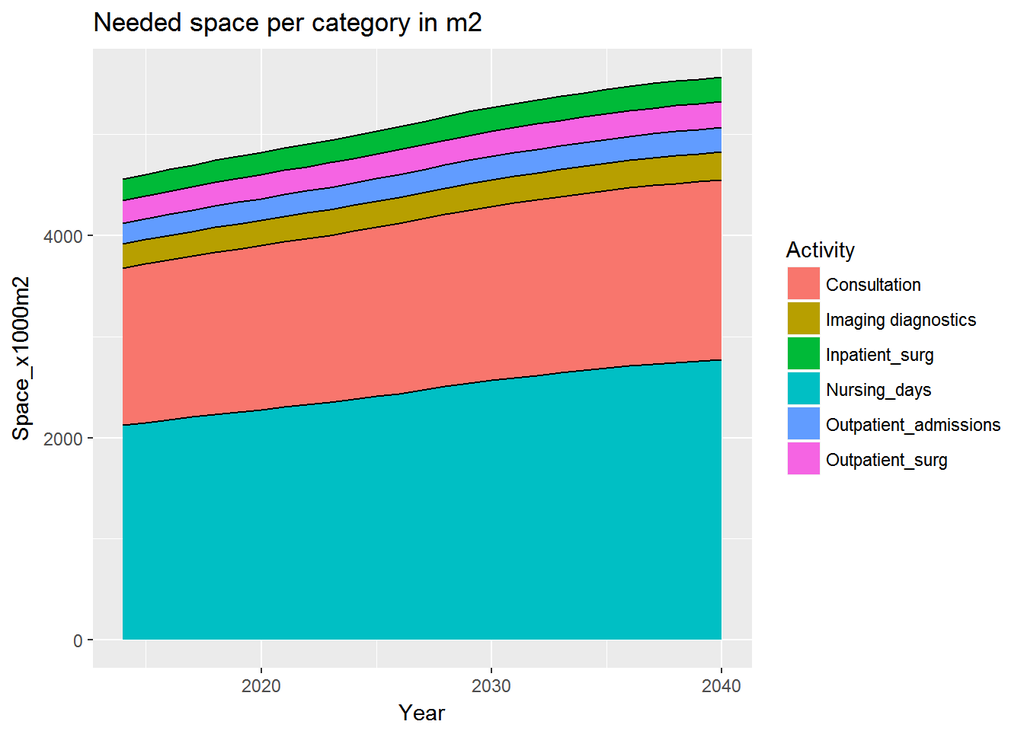

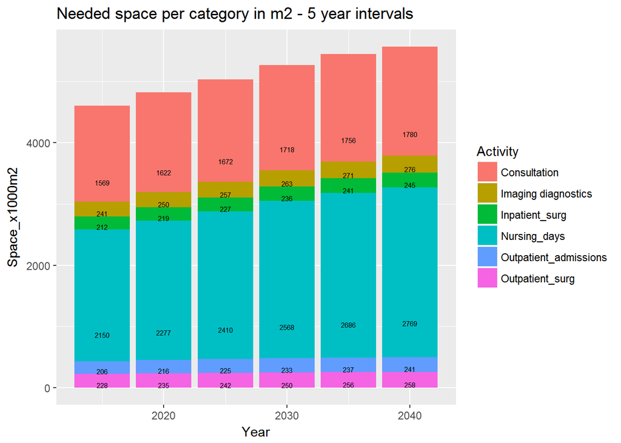

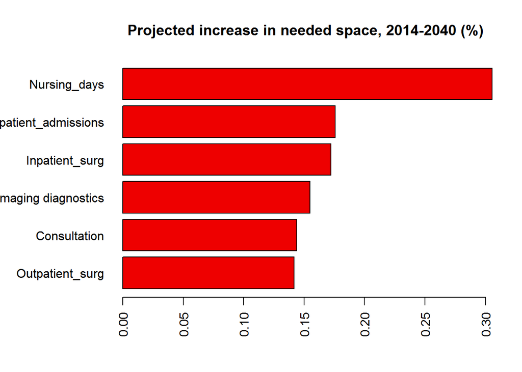

# **Part 6.** Usage of process and results

## Limitations

There are a number of limitations to the described process for aplication in real-life business problems, mainly caused by availibility of data:

1. We don’t know the current capacity, its usage or its life expectancy. So we cannot match the required space to the actual space to determine how much extra should be build for the future.
2. We assume no impact of innovation of care. However, in practice we have seen that nursing days per admission has steadily decreased. The model could be refined to include assumptions on this.
3. We have no data on specific zip-codes. Including makes it possible to forecast the space requirement for a specific hospital based on its care region.

## Usage in different context

We can use the same process for different data sets and purposes:

1. Different time horizons
2. Different countries
3. Refining for specific parts of the country, for example the care region of a hospital
4. Refining for specializations
5. Different types of care, such as youth care. Activities are different and space requirements as well, but the process is the same
6. Alternative ‘weighting’ of activities. By using m2 to weight the 6 different types of care, we get a physical result, but we could also weight the activities with average expenditure to forecast future health expenditure. Another option would be to use the investment cost per m2 of different spaces to come up with the total investment required for a hospital in a specific region.